# The Project

1. This is a project with minimal scaffolding. Expect to use the the discussion forums to gain insights! It’s not cheating to ask others for opinions or perspectives!
2. Be inquisitive, try out new things.
3. Use the previous modules for insights into how to complete the functions! You'll have to combine Pillow, OpenCV, and Pytesseract
4. There are hints provided in Coursera, feel free to explore the hints if needed. Each hint provide progressively more details on how to solve the issue. This project is intended to be comprehensive and difficult if you do it without the hints.

### The Assignment

Take a ZIP file) of images and process them, using a [library built into python](https://docs.python.org/3/library/zipfile.html) that you need to learn how to use. A ZIP file takes several different files and compresses them, thus saving space, into one single file. The files in the ZIP file we provide are newspaper images (like you saw in week 3). Your task is to write python code which allows one to search through the images looking for the occurrences of keywords and faces. E.g. if you search for "pizza" it will return a contact sheet of all of the faces which were located on the newspaper page which mentions "pizza". This will test your ability to learn a new ([library](https://docs.python.org/3/library/zipfile.html)), your ability to use OpenCV to detect faces, your ability to use tesseract to do optical character recognition, and your ability to use PIL to composite images together into contact sheets.

Each page of the newspapers is saved as a single PNG image in a file called images.zip. These newspapers are in english, and contain a variety of stories, advertisements and images. Note: This file is fairly large (~200 MB) and may take some time to work with, I would encourage you to use small_img.zip for testing.

Here's an example of the output expected. Using the small_img.zip file, if I search for the string "Christopher" I should see the following image:

[figure not shown]

If I were to use the images.zip file and search for "Mark" I should see the following image (note that there are times when there are no faces on a page, but a word is found!):

[figure not shown]

Note: That big file can take some time to process - for me it took nearly ten minutes! Use the small one for testing.

```
Reading from file is Done....

<ZipInfo filename='a-0.png' compress_type=deflate external_attr=0x20 file_size=21000053 compress_size=20835185>
<ZipInfo filename='a-1.png' compress_type=deflate external_attr=0x20 file_size=22598429 compress_size=20879041>
<ZipInfo filename='a-2.png' compress_type=deflate external_attr=0x20 file_size=3650049 compress_size=3320620>
<ZipInfo filename='a-3.png' compress_type=deflate external_attr=0x20 file_size=18646538 compress_size=16564827>


Found Items...

Image and Text Separated...

Found Image with face cordinates . Proceeding to crop them...

Made new Image...Now going to show them...
```

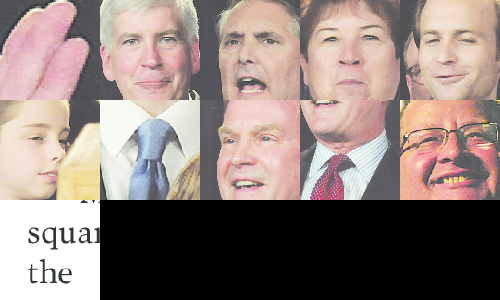

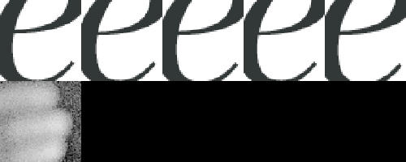

```python
from zipfile import ZipFile

from PIL import Image , ImageDraw
import pytesseract as pt
import cv2 as cv
import numpy as np

# loading the face detection classifier
face_cascade = cv.CascadeClassifier('readonly/haarcascade_frontalface_default.xml')

filename = "readonly/small_img.zip"

def readZipFile(file):
    with ZipFile(file , 'r') as myfile:
        images = myfile.infolist()
        return images

def create_image(i, j): # Function to create new image and paste the cropeed faces
  image = Image.new("RGB", (i, j), "black")
  return image

def itemsinfile(fileimages):  # Function to check all the files in zip
    for item in fileimages:
        print(item)
    print('\n')

def readtext(file): # Function to perform OCR on the images
        data = []
        with ZipFile(file , 'r') as myfile:
            images = myfile.infolist()
            for f in images:
                ifile = myfile.open(f)
                img = Image.open(ifile)
                text = pt.image_to_string(img)
                data += [[img,text]]
        return data


def Makerec(image,face_cord):    # Just a Test Function to Check the false positive and negatives
    pil_img=image.convert("RGB")
    drawing=ImageDraw.Draw(pil_img) # And lets create our drawing context
    for x,y,w,h in face_cord:
        drawing.rectangle((x,y,x+w,y+h), outline="green" , width = 10)
    display(pil_img)

def croppedfaces(image , sizes):   # Function to crop the faces from the main image and return as a list
    pil_img = image.convert('RGB')
    crp_face = []
    for x,y,w,h in sizes:
        temp = pil_img.crop((x,y,x+w,y+h))
        temp = temp.resize((100,100))
        crp_face += [temp]
    return crp_face


def detectfaces(mylist): # This Function checks for the text from OCR and bind the image with it
    face_cord = []
    for image,text in mylist:
        if 'Christopher' in text:
            opencvImage = cv.cvtColor(np.array(image), cv.COLOR_BGR2GRAY) #converting pil to opencv image
            faces = face_cascade.detectMultiScale(opencvImage,1.15)
#             Makerec(image,faces.tolist()) # Function that prints rectangle on the faces
            face_cord += [[ image,faces.tolist()]] # Creating the list of image with face cordinates

    return face_cord

# Print statements are just for testing the flow and status of the program.

fileimages = readZipFile(filename) # Fuction to read the zipfile and return imagelist

print('Reading from file is Done....\n')

itemsinfile(fileimages) # Fuction to print the items in file

print('Found Items...\n')

imagetodata = readtext(filename) # Function to bind the image with their text and return the list

print('Image and Text Separated...\n')

face_cordinates = detectfaces(imagetodata) # Function to detect the faces and return a list of image with facedata

print('Found Image with face cordinates . Proceeding to crop them...\n')

# face_cordinates = [image , face_boxes]

cropped_faces = []

for image , size in face_cordinates:
    face_list = croppedfaces(image,size)
    temp = face_list[0]
    new = create_image((temp.width * 5) ,temp.height * ((len(face_list)//5)+1))
    x = 0
    y = 0
    for face in face_list:
        new.paste(face,(x,y))
        if x == new.width:
            x = 0
            y = y + face.height
        else:
            x += face.width
    cropped_faces += [new]

print('Made new Image...Now going to show them...\n')

for faces in cropped_faces:
    display(faces)
```